# Delays-Copy1

### Taxi times by airport and airline

Industry Average Taxi-Out takes 17 minutes, while Taxi-In takes 7 minutes.  
These figures represent the time between when the plane is at the terminal and in the air.  
This could be an indication of prior delays in the airport operations.  
JFK has the slowest Taxi-Out time of 27 minutes, while MIA has the slowest Taxi-In time of 8.5 minutes. Additional data is needed to determine whether these times are related to the size of the runway.

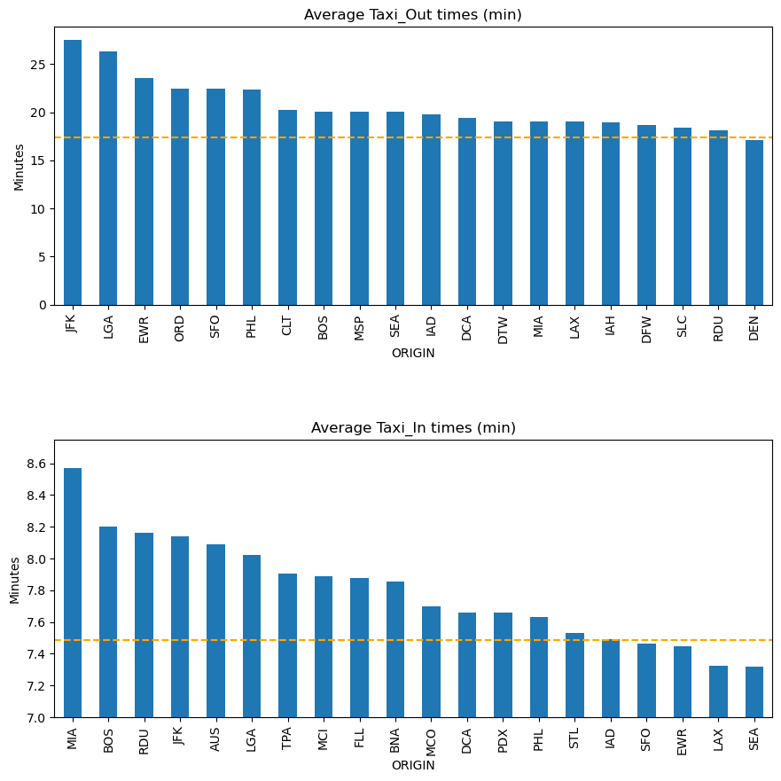

```python
# subplots combined
fig, axes = plt.subplots(nrows=2, ncols=1, figsize=(10, 10))

# Airport Avg Taxi_In times (min)
top_airports.groupby('ORIGIN')['TAXI_IN'].mean().sort_values(ascending=False).head(20).plot(kind='bar', ax=axes[1])
taxi_in_avg = top_airlines['TAXI_IN'].mean()
axes[1].axhline(y=taxi_in_avg, linestyle='--', color='orange', label='Industry_Avg')
axes[1].set_title("Average Taxi_In times (min)")
axes[1].set_ylabel('Minutes')
axes[1].set_ylim(7, 8.75)

# Airport Avg Taxi_Out times (min)
top_airports.groupby('ORIGIN')['TAXI_OUT'].mean().sort_values(ascending=False).head(20).plot(kind='bar', ax=axes[0])
taxi_out_avg = top_airlines['TAXI_OUT'].mean()
axes[0].axhline(y=taxi_out_avg, linestyle='--', color='orange', label='Industry_Avg')
axes[0].set_title("Average Taxi_Out times (min)")
axes[0].set_ylabel('Minutes')

plt.tight_layout(pad=5)
plt.show()
```

### Flight Cancellations

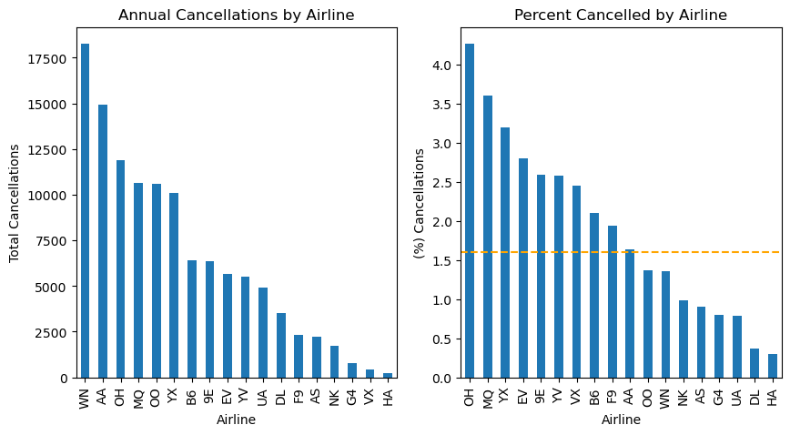

```python
# subplots combined
fig, axes = plt.subplots(nrows=1, ncols=2, figsize=(10, 5))

cdf = df[df['CANCELLED']==1]
cdf.groupby('OP_CARRIER').sum()['CANCELLED'].sort_values(ascending=False).plot(kind='bar', ax=axes[0])
axes[0].set_title("Annual Cancellations by Airline")
axes[0].set_xlabel('Airline')
axes[0].set_ylabel('Total Cancellations')




# Percent Canceled by airline
canceled_flights = df[df['CANCELLED'] == 1]
canceled_flights
canceled_count = canceled_flights['OP_CARRIER'].value_counts()
canceled_count
total_flights = df['OP_CARRIER'].value_counts()
perc_canceled = canceled_count / total_flights * 100
perc_canceled.sort_values(ascending= False).head(20).plot(kind='bar', ax=axes[1])

second_line = 1.6
axes[1].axhline(y=second_line, linestyle='--', color='orange', label='Industry_Avg' )

axes[1].set_title("Percent Cancelled by Airline")
axes[1].set_xlabel('Airline')
axes[1].set_ylabel('(%) Cancellations')
plt.show()
```

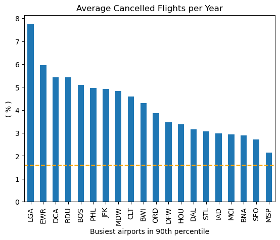

```python
# Average cancelled flights by Airport (%)



mean_cancelled_airports_origin = top_airports.groupby('ORIGIN').mean(numeric_only=True)['CANCELLED']*100
mean_cancelled_airports_dest = top_airports.groupby('DEST').mean(numeric_only=True)['CANCELLED']*100
mean_cancelled_airports = mean_cancelled_airports_origin + mean_cancelled_airports_dest
mean_cancelled_airports.sort_values(ascending=False).head(20).plot(kind='bar')

second_line = 1.6
plt.axhline(y=second_line, linestyle='--', color='orange', label='Industry_Avg' )

plt.title("Average Cancelled Flights per Year")
plt.ylabel('( % )')
plt.xlabel('Busiest airports in 90th percentile')
plt.show()
```

```python
mean_cancelled_carriers = df.groupby('OP_CARRIER').mean()['CANCELLED'].sort_values(ascending=False)*100
```

#### Wednesday has the most cancellations at 1.98% compared to Saturday with the lowest (1.01%)

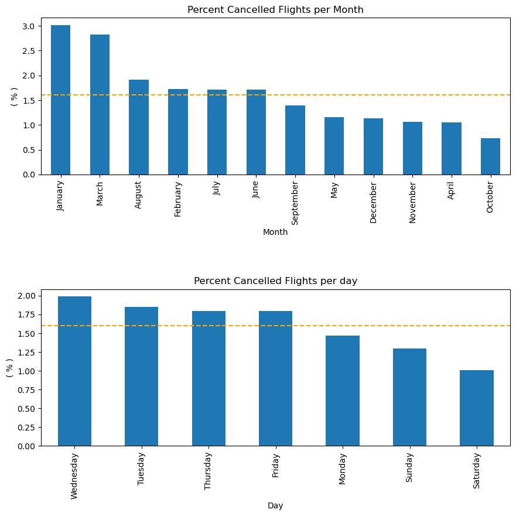

```python
# subplots
fig, axes = plt.subplots(nrows=2, ncols=1, figsize=(10, 10))

# Cancelled flights by month (%)
cdf['FL_DATE'] = pd.to_datetime(cdf['FL_DATE'])
cdf['Month'] = cdf['FL_DATE'].dt.month_name()
cancelled_month_count = cdf['Month'].value_counts()
((cancelled_month_count / month_count)*100).sort_values(ascending=False).plot(kind='bar', ax=axes[0])

# month_order = ['January','February','March','April','May','June','July','August','September','October','November','December']
# cdf['Month'] = pd.Categorical(cdf['Month'], categories=month_order, ordered=True)

sl2 = 1.6
axes[0].axhline(y=second_line, linestyle='--', color='orange', label='Industry_Avg' )
axes[0].set_title("Percent Cancelled Flights per Month")
axes[0].set_xlabel('Month')
axes[0].set_ylabel('( % )')



# Cancelled flights by day (%)

# defining Day column
cdf['DAY'] = cdf['FL_DATE'].dt.day_name()
cancelled_day_count = cdf['DAY'].value_counts()
((cancelled_day_count / day_count)*100).sort_values(ascending=False).plot(kind='bar', ax=axes[1])


axes[1].axhline(y=sl2, linestyle='--', color='orange', label='Industry_Avg' )
axes[1].set_title("Percent Cancelled Flights per day")
axes[1].set_xlabel('Day')
axes[1].set_ylabel('( % )')
plt.tight_layout(pad=5.0)
plt.show()
```